# Anchoring Bias in the Stock Market

Author

Alan Schulz-Diaz and Wesley Stone

Published

December 17, 2024

## Driving Question

We came to this project with one simple question: are there cognitive biases that impact the daily highs and lows in which stocks are traded? In theory, stock prices should be random, as traders’ valuations depend on a multitude of factors that are impossible to predict.

However, humans execute transactions and we wondered if there is a tendency for daily high and low prices to cluster around rounded numbers. At first, we thought the best approach would be to investigate the nominal value of a stock. But quickly, we realized stocks’ tendency to trade in values less than 5 dollars was simply because there are more small companies listed in the stock market than larger ones. Then, we came up with the idea of investigating if the last two decimal places of a stock, essentially, its ending cent value, clustered around rounded numbers.

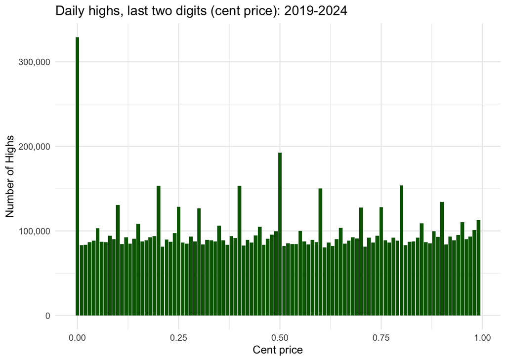

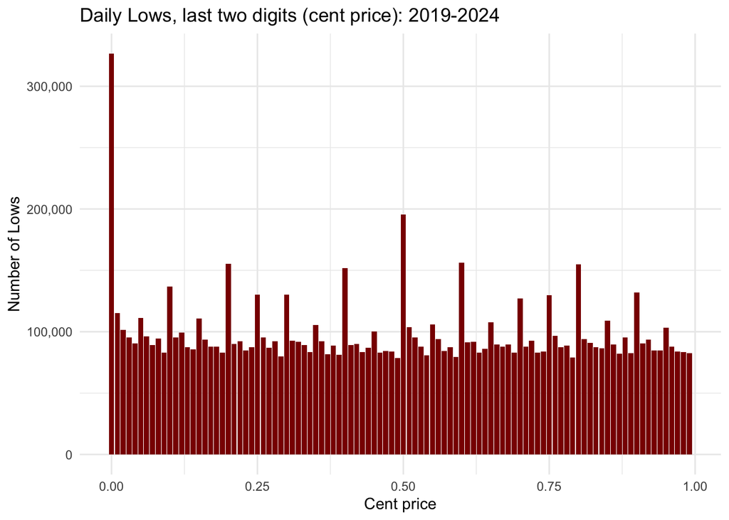

## Analysis

These graphs present compelling evidence of anchoring bias. There are high peaks at 0 and 50 cents, as well as other round numbers such as multiples of 10 and 25.

If we look closer, another insight we get from these graphs is highs and lows both peak at rounded cent values, but they behave slightly different on how they approach to that peak. When approaching a daily high, traders keep buying until it reaches the 0 value, with lots of trades ending at 99 cents. Instead, when approaching a daily low, traders will buy at .01 and stop buying at .99. This behavior further reinforces the trend, as these barriers act as as support and tension price points.

However, one of the concerns we had was that low volume stocks were driving this behavior. For example, some stocks can be as pricey as $200,000, and those stocks are usually traded at rounded numbers and by very few individuals. So we created two interactive shiny apps to allow users to view the trends of their choice.

First, we divided all stocks into five categories according to their median volume of daily trades. The user can explore the company size, metric and date of their choice.

[interactive chart not shown]

Whatever volume you look at, the trend generally maintains. People like rounded numbers and particularly .00 and .50.

The second shiny is for individual stocks. To keep the dropdown manageable, we limited the options to stocks from the S&P 500, minus the seven companies that did not appear in our dataset.

[interactive chart not shown]

Thanks for checking out our project! We hope you found it as interesting as we did.